# py-template-regression_example

## version 03.0

### July 13, 2018

Template Credit: Adapted from a template made available by Dr. Jason Brownlee of Machine Learning Mastery. https://machinelearningmastery.com/

SUMMARY: [Sample Paragraph - The purpose of this project is to construct prediction model using various machine learning algorithms and to document the end-to-end steps using a template. The Boston Housing dataset is a classic regression situation where we are trying to predict the value of a continuous variable.]

INTRODUCTION: [Sample Paragraph - The dataset for this project originates from the UCI Machine Learning Repository. The Boston housing data was collected in 1978 and each of the 506 entries represent aggregated data about 14 features for homes from various suburbs in Boston, Massachusetts.]

Dataset Used: Boston Housing

Dataset Reference: https://archive.ics.uci.edu/ml/datasets/housing

One potential source of performance benchmarks: ttps://www.kaggle.com/c/boston-housing

The project aims to touch on the following areas:

- Document a predictive modeling problem end-to-end.
- Explore data cleaning and transformation options
- Explore non-ensemble and ensemble algorithms for baseline model performance
- Explore algorithm tuning techniques for improving model performance

Any predictive modeling machine learning project genrally can be broken down into about six major tasks:

1. Prepare Problem
2. Summarize Data
3. Prepare Data
4. Model and Evaluate Algorithms
5. Improve Accuracy or Results
6. Finalize Model and Present Results

## Section 1 - Prepare Problem

### 1.a) Load ibraries

```python
import numpy as np
from numpy import arange
from matplotlib import pyplot
from pandas import read_csv
from pandas import set_option
from pandas.plotting import scatter_matrix
from sklearn.preprocessing import StandardScaler
from sklearn.model_selection import train_test_split
from sklearn.model_selection import KFold
from sklearn.model_selection import cross_val_score
from sklearn.model_selection import GridSearchCV
from sklearn.metrics import mean_squared_error
from sklearn.pipeline import Pipeline
from sklearn.linear_model import LinearRegression
from sklearn.linear_model import Ridge
from sklearn.linear_model import Lasso
from sklearn.linear_model import ElasticNet
from sklearn.tree import DecisionTreeRegressor
from sklearn.neighbors import KNeighborsRegressor
from sklearn.svm import SVR
from sklearn.ensemble import RandomForestRegressor
from sklearn.ensemble import ExtraTreesRegressor
from sklearn.ensemble import AdaBoostRegressor
from sklearn.ensemble import GradientBoostingRegressor
from sklearn.externals.joblib import dump
from sklearn.externals.joblib import load
from datetime import datetime
```

### 1.b) Load dataset

```python
startTimeScript = datetime.now()

inputFile = 'boston-housing.data.csv'
names = ['CRIM', 'ZN', 'INDUS', 'CHAS', 'NOX', 'RM', 'AGE', 'DIS', 'RAD', 'TAX', 'PTRATIO', 'B', 'LSTAT', 'MEDV']
entireDataset = read_csv(inputFile, delim_whitespace=True, names=names)

# Standardize the class column to the name of targetVar
entireDataset = entireDataset.rename(columns={'MEDV': 'targetVar'})
```

## Section 2 - Summarize Data

To gain a better understanding of the data that we have on-hand, we will leverage a number of descriptive statistics and data visualization techniques. The plan is to use the results to consider new questions, review assumptions, and validate hypotheses that we can investigate later with specialized models.

### 2.a) Descriptive statistics

```python
# Set up a variable for the total number of attribute columns (totAttr)
totCol = len(entireDataset.columns)
totAttr = totCol-1
# Set up the number of row and columns for visualization display. dispRow * dispCol should be >= totAttr
dispCol = 4
if totAttr % dispCol == 0 :
    dispRow = totAttr // dispCol
else :
    dispRow = (totAttr // dispCol) + 1
```

#### 2.a.i) Peek at the data itself.

```python
print(entireDataset.head(20))
```

```
       CRIM    ZN  INDUS  CHAS    NOX     RM    AGE     DIS  RAD    TAX  \
0   0.00632  18.0   2.31     0  0.538  6.575   65.2  4.0900    1  296.0
1   0.02731   0.0   7.07     0  0.469  6.421   78.9  4.9671    2  242.0
2   0.02729   0.0   7.07     0  0.469  7.185   61.1  4.9671    2  242.0
3   0.03237   0.0   2.18     0  0.458  6.998   45.8  6.0622    3  222.0
4   0.06905   0.0   2.18     0  0.458  7.147   54.2  6.0622    3  222.0
5   0.02985   0.0   2.18     0  0.458  6.430   58.7  6.0622    3  222.0
6   0.08829  12.5   7.87     0  0.524  6.012   66.6  5.5605    5  311.0
7   0.14455  12.5   7.87     0  0.524  6.172   96.1  5.9505    5  311.0
8   0.21124  12.5   7.87     0  0.524  5.631  100.0  6.0821    5  311.0
9   0.17004  12.5   7.87     0  0.524  6.004   85.9  6.5921    5  311.0
10  0.22489  12.5   7.87     0  0.524  6.377   94.3  6.3467    5  311.0
11  0.11747  12.5   7.87     0  0.524  6.009   82.9  6.2267    5  311.0
12  0.09378  12.5   7.87     0  0.524  5.889   39.0  5.4509    5  311.0
13  0.62976   0.0   8.14     0  0.538  5.949   61.8  4.7075    4  307.0
```

[output cut: 28 more lines]

#### 2.a.ii) Dimensions of the dataset.

```python
print(entireDataset.shape)
```

```
(506, 14)
```

#### 2.a.iii) Types of the attributes.

```python
print(entireDataset.dtypes)
```

```
CRIM         float64
ZN           float64
INDUS        float64
CHAS           int64
NOX          float64
RM           float64
AGE          float64
DIS          float64
RAD            int64
TAX          float64
PTRATIO      float64
B            float64
LSTAT        float64
targetVar    float64
dtype: object
```

#### 2.a.iv) Statistical summary of all attributes.

```python
print(entireDataset.describe())
```

```
             CRIM          ZN       INDUS        CHAS         NOX          RM  \
count  506.000000  506.000000  506.000000  506.000000  506.000000  506.000000
mean     3.613524   11.363636   11.136779    0.069170    0.554695    6.284634
std      8.601545   23.322453    6.860353    0.253994    0.115878    0.702617
min      0.006320    0.000000    0.460000    0.000000    0.385000    3.561000
25%      0.082045    0.000000    5.190000    0.000000    0.449000    5.885500
50%      0.256510    0.000000    9.690000    0.000000    0.538000    6.208500
75%      3.677082   12.500000   18.100000    0.000000    0.624000    6.623500
max     88.976200  100.000000   27.740000    1.000000    0.871000    8.780000

              AGE         DIS         RAD         TAX     PTRATIO           B  \
count  506.000000  506.000000  506.000000  506.000000  506.000000  506.000000
mean    68.574901    3.795043    9.549407  408.237154   18.455534  356.674032
std     28.148861    2.105710    8.707259  168.537116    2.164946   91.294864
min      2.900000    1.129600    1.000000  187.000000   12.600000    0.320000
25%     45.025000    2.100175    4.000000  279.000000   17.400000  375.377500
50%     77.500000    3.207450    5.000000  330.000000   19.050000  391.440000
75%     94.075000    5.188425   24.000000  666.000000   20.200000  396.225000
max    100.000000   12.126500   24.000000  711.000000   22.000000  396.900000

            LSTAT   targetVar
count  506.000000  506.000000
mean    12.653063   22.532806
std      7.141062    9.197104
min      1.730000    5.000000
25%      6.950000   17.025000
50%     11.360000   21.200000
75%     16.955000   25.000000
max     37.970000   50.000000
```

#### 2.a.v) Summarize the levels of the class attribute.

```python
# Not applicable for this iteration of the project.
# print(entireDataset.groupby('targetVar').size())
```

#### 2.a.v) Count missing values.

```python
print(entireDataset.isnull().sum())
```

```
CRIM         0
ZN           0
INDUS        0
CHAS         0
NOX          0
RM           0
AGE          0
DIS          0
RAD          0
TAX          0
PTRATIO      0
B            0
LSTAT        0
targetVar    0
dtype: int64
```

### 2.b) Data visualizations

##### 2.b.i) Univariate plots to better understand each attribute

```python
attributeOnly = entireDataset.drop(columns=['targetVar'])
```

```python
# Set figure width to 16 and height to 12 (4:3 aspect ratio)
fig_size = pyplot.rcParams["figure.figsize"]
fig_size[0] = 16
fig_size[1] = 12
pyplot.rcParams["figure.figsize"] = fig_size
```

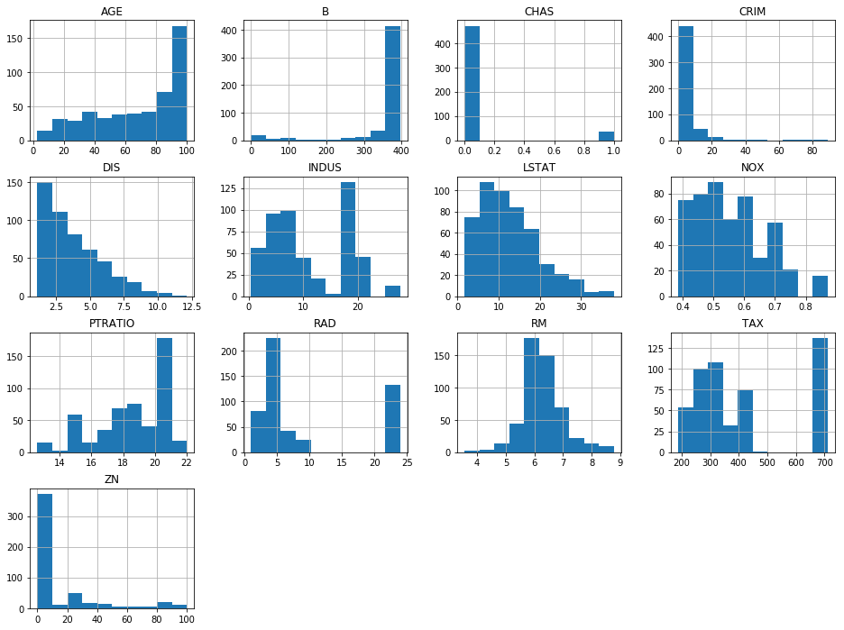

```python
# Histograms for each attribute
attributeOnly.hist()
pyplot.show()
```

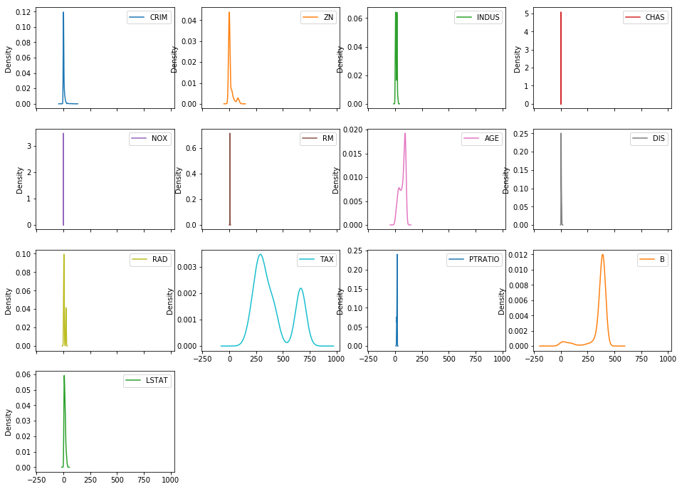

```python
# Density plot for each attribute
attributeOnly.plot(kind='density', subplots=True, layout=(dispRow,dispCol))
pyplot.show()
```

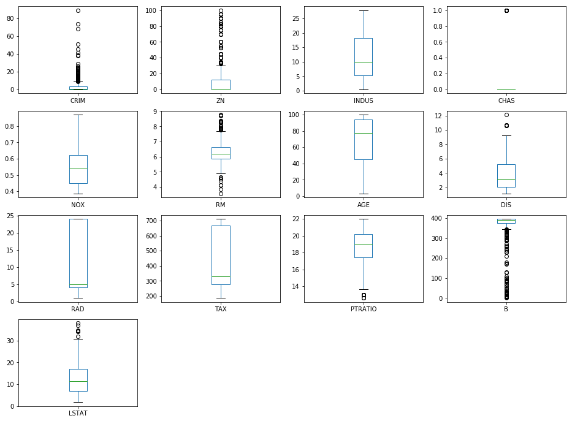

```python
# Box and Whisker plot for each attribute
attributeOnly.plot(kind='box', subplots=True, layout=(dispRow,dispCol))
pyplot.show()
```

#### 2.b.ii) Multivariate plots to better understand the relationships between attributes

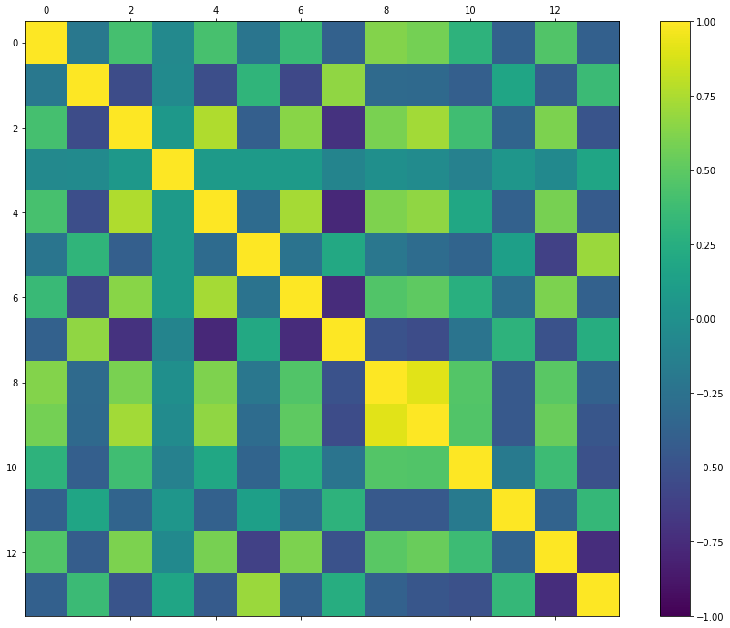

```python
# Correlation matrix
fig = pyplot.figure()
ax = fig.add_subplot(111)
cax = ax.matshow(entireDataset.corr(), vmin=-1, vmax=1)
fig.colorbar(cax)
pyplot.show()
```

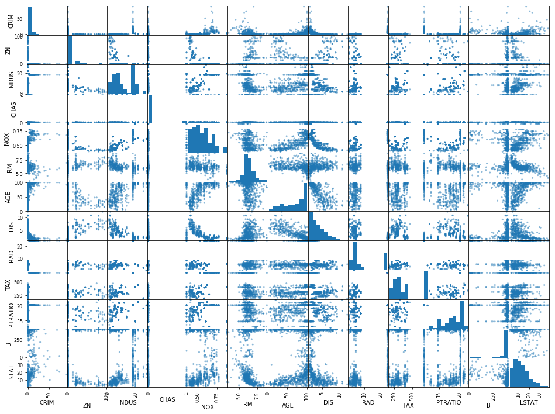

```python
# Scatterplot matrix
scatter_matrix(attributeOnly)
pyplot.show()
```

## Section 3 - Prepare Data

Some dataset may require additional preparation activities that will best exposes the structure of the problem and the relationships between the input attributes and the output variable. Some data-prep tasks might include:

- Cleaning data by removing duplicates, marking missing values and even imputing missing values.
- Feature selection where redundant features may be removed.
- Data transforms where attributes are scaled or redistributed in order to best expose the structure of the problem later to learning algorithms.

### 3.a) Data Cleaning

```python
# Not applicable for this iteration of the project.
```

### 3.b) Feature Selection

```python
# Not applicable for this iteration of the project.
```

### 3.c) Data Transforms

```python
# Not applicable for this iteration of the project.
```

### 3.d) Split-out training and validation datasets

We create a training dataset (variable name "training") and a validation dataset (variable name "validation").

```python
seedNum = 888
totAttr = len(entireDataset.columns)-1
array = entireDataset.values
X_entire = array[:,0:totAttr]
Y_entire = entireDataset['targetVar'].values
validation_size = 0.30
X_train, X_validation, Y_train, Y_validation = train_test_split(X_entire, Y_entire, test_size=validation_size, random_state=seedNum)
print("X_entire.shape: {} Y_entire.shape: {}".format(X_entire.shape, Y_entire.shape))
print("X_train.shape: {} Y_train.shape: {}".format(X_train.shape, Y_train.shape))
print("X_validation.shape: {} Y_validation.shape: {}".format(X_validation.shape, Y_validation.shape))
print ('Total time for data handling and visualization:',(datetime.now() - startTimeScript))
```

```
X_entire.shape: (506, 13) Y_entire.shape: (506,)
X_train.shape: (354, 13) Y_train.shape: (354,)
X_validation.shape: (152, 13) Y_validation.shape: (152,)
Total time for data handling and visualization: 0:00:09.353644
```

## 4. Model and Evaluate Algorithms

After the data-prep, we next work on finding a workable model by evaluating a subset of machine learning algorithms that are good at exploiting the structure of the training. The typical evaluation tasks include:

- Defining test options such as cross validation and the evaluation metric to use.
- Spot checking a suite of linear and nonlinear machine learning algorithms.
- Comparing the estimated accuracy of algorithms.

For this project, we will evaluate four linear, three non-linear, and four ensemble algorithms:

Linear Algorithms: Linear Regression, Ridge Regression, LASSO Regression, and Elastic Net Regression

Non-Linear Algorithms: Decision Trees (CART), k-Nearest Neighbors, and Support Vector Machine

Ensemble Algorithms: Random Forest, Extra Trees, AdaBoost, and Stochastic Gradient Boosting

The random number seed is reset before each run to ensure that the evaluation of each algorithm is performed using the same data splits. It ensures the results are directly comparable.

### 4.a) Set test options and evaluation metric

```python
# Run algorithms using 10-fold cross validation
num_folds = 10
scoring = 'neg_mean_squared_error'
```

```python
# Set up Algorithms Spot-Checking Array
models = []
models.append(('LR', LinearRegression()))
models.append(('RR', Ridge()))
models.append(('LASSO', Lasso()))
models.append(('EN', ElasticNet()))
models.append(('CART', DecisionTreeRegressor(random_state=seedNum)))
models.append(('KNN', KNeighborsRegressor()))
models.append(('SVM', SVR()))
models.append(('RF', RandomForestRegressor(random_state=seedNum)))
models.append(('ET', ExtraTreesRegressor(random_state=seedNum)))
models.append(('AB', AdaBoostRegressor(random_state=seedNum)))
models.append(('GBM', GradientBoostingRegressor(random_state=seedNum)))
results = []
names = []
metrics = []
```

```python
# Generate model in turn
for name, model in models:
	startTimeModule = datetime.now()
	kfold = KFold(n_splits=num_folds, random_state=seedNum)
	cv_results = cross_val_score(model, X_train, Y_train, cv=kfold, scoring=scoring)
	results.append(cv_results)
	names.append(name)
	metrics.append(cv_results.mean())
	msg = "%s: %f (%f)" % (name, cv_results.mean(), cv_results.std())
	print(msg)
	print ('Model training time:',(datetime.now() - startTimeModule))
print ('Average metrics ('+scoring+') from all models:',np.mean(metrics))
```

```
LR: -25.612033 (13.351275)
Model training time: 0:00:00.019970
RR: -25.790544 (13.693551)
Model training time: 0:00:00.016989
LASSO: -29.758615 (14.872414)
Model training time: 0:00:00.017989
EN: -29.428369 (14.921289)
Model training time: 0:00:00.016991
CART: -22.339652 (15.928947)
Model training time: 0:00:00.029982
KNN: -50.328254 (29.718809)
Model training time: 0:00:00.012994
SVM: -88.911727 (29.338475)
Model training time: 0:00:00.105938
RF: -14.981121 (11.652530)
Model training time: 0:00:00.207883
ET: -15.083016 (9.266903)
Model training time: 0:00:00.157909
AB: -14.569617 (9.478712)
Model training time: 0:00:00.675613
GBM: -13.145342 (10.777361)
Model training time: 0:00:00.361811
Average metrics (neg_mean_squared_error) from all models: -29.99529907604939
```

### 4.b) Spot-checking baseline algorithms

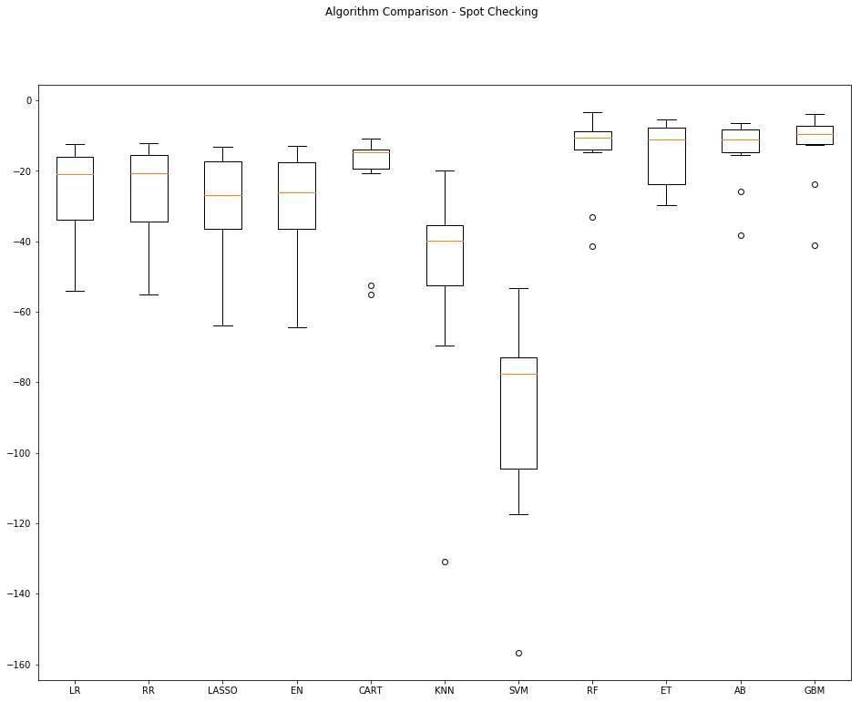

```python
fig = pyplot.figure()
fig.suptitle('Algorithm Comparison - Spot Checking')
ax = fig.add_subplot(111)
pyplot.boxplot(results)
ax.set_xticklabels(names)
pyplot.show()
```

## Section 5 - Improve Accuracy

After we achieve a short list of machine learning algorithms with good level of accuracy, we can leverage ways to improve the accuracy of the models.

### 5.a) Algorithm Tuning

```python
# Set up the comparison array
results = []
names = []
```

```python
# Tuning algorithm #1 - AdaBoost
startTimeModule = datetime.now()
paramGrid1 = dict(n_estimators=np.array([100,200,300,400,500]))
model1 = AdaBoostRegressor(random_state=seedNum)
kfold = KFold(n_splits=num_folds, random_state=seedNum)
grid1 = GridSearchCV(estimator=model1, param_grid=paramGrid1, scoring=scoring, cv=kfold)
grid_result1 = grid1.fit(X_train, Y_train)

print("Best: %f using %s" % (grid_result1.best_score_, grid_result1.best_params_))
results.append(grid_result1.cv_results_['mean_test_score'])
names.append('AB')
means = grid_result1.cv_results_['mean_test_score']
stds = grid_result1.cv_results_['std_test_score']
params = grid_result1.cv_results_['params']
for mean, stdev, param in zip(means, stds, params):
    print("%f (%f) with: %r" % (mean, stdev, param))
print ('Model training time:',(datetime.now() - startTimeModule))
```

```
Best: -14.275962 using {'n_estimators': 400}
-14.906343 (9.399826) with: {'n_estimators': 100}
-14.474015 (9.011891) with: {'n_estimators': 200}
-14.462061 (8.744763) with: {'n_estimators': 300}
-14.275962 (8.544753) with: {'n_estimators': 400}
-14.494085 (8.502470) with: {'n_estimators': 500}
Model training time: 0:00:20.141471
```

```python
# Tuning algorithm #2 - Random Forest
startTimeModule = datetime.now()
paramGrid2 = dict(n_estimators=np.array([20,40,60,80,100]))
model2 = RandomForestRegressor(random_state=seedNum)
kfold = KFold(n_splits=num_folds, random_state=seedNum)
grid2 = GridSearchCV(estimator=model2, param_grid=paramGrid2, scoring=scoring, cv=kfold)
grid_result2 = grid2.fit(X_train, Y_train)

print("Best: %f using %s" % (grid_result2.best_score_, grid_result2.best_params_))
results.append(grid_result2.cv_results_['mean_test_score'])
names.append('RF')
means = grid_result2.cv_results_['mean_test_score']
stds = grid_result2.cv_results_['std_test_score']
params = grid_result2.cv_results_['params']
for mean, stdev, param in zip(means, stds, params):
    print("%f (%f) with: %r" % (mean, stdev, param))
print ('Model training time:',(datetime.now() - startTimeModule))
```

```
Best: -13.550562 using {'n_estimators': 40}
-14.157638 (11.558897) with: {'n_estimators': 20}
-13.550562 (11.958646) with: {'n_estimators': 40}
-14.114891 (12.623699) with: {'n_estimators': 60}
-14.019512 (12.675438) with: {'n_estimators': 80}
-14.069409 (12.713605) with: {'n_estimators': 100}
Model training time: 0:00:06.586231
```

```python
# Tuning algorithm #3 - Stochastic Gradient Boosting
startTimeModule = datetime.now()
paramGrid3 = dict(n_estimators=np.array([50,75,100,125,150]))
model3 = GradientBoostingRegressor(random_state=seedNum)
kfold = KFold(n_splits=num_folds, random_state=seedNum)
grid3 = GridSearchCV(estimator=model3, param_grid=paramGrid3, scoring=scoring, cv=kfold)
grid_result3 = grid3.fit(X_train, Y_train)

print("Best: %f using %s" % (grid_result3.best_score_, grid_result3.best_params_))
results.append(grid_result3.cv_results_['mean_test_score'])
names.append('GBM')
means = grid_result3.cv_results_['mean_test_score']
stds = grid_result3.cv_results_['std_test_score']
params = grid_result3.cv_results_['params']
for mean, stdev, param in zip(means, stds, params):
    print("%f (%f) with: %r" % (mean, stdev, param))
print ('Model training time:',(datetime.now() - startTimeModule))
```

```
Best: -13.092781 using {'n_estimators': 100}
-13.819891 (11.346641) with: {'n_estimators': 50}
-13.147642 (10.944549) with: {'n_estimators': 75}
-13.092781 (10.732011) with: {'n_estimators': 100}
-13.179800 (10.883205) with: {'n_estimators': 125}
-13.232407 (10.999644) with: {'n_estimators': 150}
Model training time: 0:00:01.950884
```

### 5.b) Compare Algorithms After Tuning

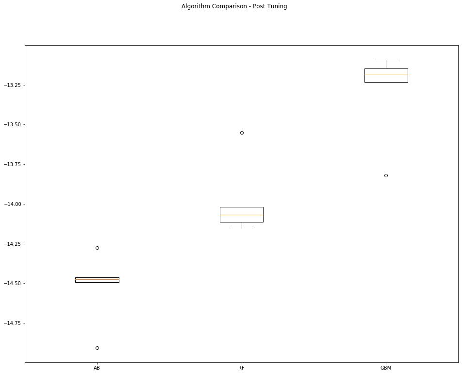

```python
fig = pyplot.figure()
fig.suptitle('Algorithm Comparison - Post Tuning')
ax = fig.add_subplot(111)
pyplot.boxplot(results)
ax.set_xticklabels(names)
pyplot.show()
```

## Section 6 - Finalize Model

Once we have narrow down to a model that we believe can make accurate predictions on unseen data, we are ready to finalize it. Finalizing a model may involve sub-tasks such as:

- Using an optimal model tuned to make predictions on unseen data.
- Creating a standalone model using the tuned parameters
- Saving an optimal model to file for later use.

### 6.a) Predictions on validation dataset

```python
model = GradientBoostingRegressor(n_estimators=100, random_state=seedNum)
model.fit(X_train, Y_train)
predictions = model.predict(X_validation)
print(mean_squared_error(Y_validation, predictions))
```

```
8.587245063571602
```

### 6.b) Create standalone model on entire training dataset

```python
startTimeModule = datetime.now()
finalModel = GradientBoostingRegressor(n_estimators=100)
finalModel.fit(X_entire, Y_entire)
print ('Model training time:',(datetime.now() - startTimeModule))
```

```
Model training time: 0:00:00.067959
```

### 6.c) Save model for later use

```python
# modelName = 'finalModel_BinaryClass.sav'
# dump(finalModel, modelName)

print ('Total time for the script:',(datetime.now() - startTimeScript))
```

```
Total time for the script: 0:00:40.506815
```